# Citi Bike

2022-04-20

## Domain knowledge (1.1)

[figure not shown]

Citi Bike is a New York City’s bike share system. They are the biggest bike sharing in US. Their main focus is not just to offer an easy and cheap service to transport users from point A to B; Citi Bike offers a transportation system that helps the environment, the local community and the users themselves.

A green alternative to other urban means of transportation.

**HOW DOES IT WORK?**

Citi Bike works in 4 steps:

- *Join* : by downloading the mobile phone app and subscribing to the service at a price of $15 per month, $15 for a day pass or $3.99 for a single time trip.
- *Unlock* ; once your account is settled you need only to find a bike nearby and ride on.
- *Ride* : the city is yours, take as many short rides as you need! (but keep it within 30 minutes if you are not a subscriber)
- *Return* : when you reach your destination, return the bike to one of the many Citi Bike’s stations around the city and secure it in there.

**HOW SUCCESSFUL ARE THEY ?**

Citi Bike started in 2013 with 5000 subscribers and 6000 bikes throughout hundreds of stations in Manhattan and Brooklyn. In the next 8 years they didn’t grow just in numbers (more than 150,000 subscribers and 100,000,000 trips by July 2020), they have become a part of New York:

In 2013 by pedalling, Citi Bike users powered the Times Square New Year’s Eve Ball and in June of the same year they were on the cover page of The New Yorker.

[figure not shown]

Citi Bike are enjoyed a stunning success, they offer a cheaper and greener service for quick trips around town, promising an agile mean of transportation in a cluttered city like New York.

## Business requirements (1.2)

I will first familiarise with the data and in doing this I’ll consider any ethics for this data set, like if the data is truthfully presented. Then move on any eventual wrangling and cleaning. I will save the result in a new .csv file called “nyc_bikes_clean”. In a R Studio Notebook, I’ll start the analysis and eventually create the visuals and chose those to be part of this Markdown document and my presentation. Regarding the presentation, I’ll create PowerPoint slide with the visuals. I’ll keep a coherent style through the Markdown document and the PowerPoint slides, with the use of Citi Bank branding colours for the visuals and using the same font for both documents.

## Business processes and data flow (1.3)

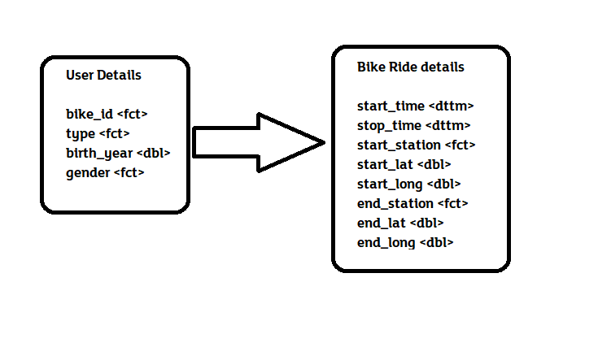

## Data visualisation as a tool for decision-making (1.4)

This report can help Citi Bank to identify their target user and if they do have one or not.

In particular I want to analyse difference and relations between subscribers and occasional user:

- What are the difference between these two types of customers?
- Is the subscribing system too rigid? Can it be adjusted to accommodate the needs of those who don’t want to commit to one year plan?

## Data types (1.5)

After the cleaning of the raw data set, the data frame I am going to work on is composed of these variable and types:

- bike_id, , **ID of the bike hired**
- start_time <S3: POSIXct>, **time the bike was hired**
- stop_time <S3: POSIXct>, **time the bike was returned**
- rent_length_minutes , **the total in minutes that the bike was lent**
- start_station , **where the bike was taken**
- end_station , **where it was returned**
- start_lat , **latitude where it was taken**
- start_long , **longitude where it was taken**
- end_lat , **latitude where it was returned**
- end_long , **longitude where it was returned**
- user_type , **user type, subscriber or a one-time user**
- user_age , **the user age**
- birth_year , **the user birth year**
- gender , users’ **the user gender**
- hire_year , **a column useful for calculating bike hire by year**
- hire_month , **a column useful for calculating bike hire by month**
- hire_day , **a column useful for calculating bike hire by day**

## Data quality and data bias (1.6)

The dataset is not dramatically messy, it didn’t require any major cleaning. I have noticed a couple of small out of scale values (133 old person riding a bike?). Another off value is the close to two-hundred 49 years old occasional Citi Bike users. This is way off the average number of other occasional users divided by age we see in the data set. I’ve decided to not exclude this from the analysis; unlike the ultra-centenary bikers although odd (very, very odd) this doesn’t look like a mistake made while collecting data.

## Preparing data for visualisation (1.7)

As said above, the data doesn’t need any major cleaning.

Belove my process of data cleaning:

Libraries for the cleaning process:

```r
library(tsibbledata)
library(lubridate)
library(sf)
library(leaflet)
library(tidyverse)
```

Storing the data in a new variable.

```r
ncy_bikes_df <- nyc_bikes
```

Creating a new column `rent_length`, using the lubridate function as.period() to generate a value for the length of the time a bike was rented. Then changing it in a numeric value and specify they are minutes. Relocating this new column after `stop_time`.

```r
ncy_bikes_df <- ncy_bikes_df %>%
  mutate(rent_lengt_minutes = as.period(stop_time - start_time),
         rent_lengt_minutes = as.numeric(rent_lengt_minutes, "minutes")) %>%
  relocate(rent_lengt_minutes, .after = stop_time)
```

Creating a new column each for year, month and day. I know this looks messy, and it is, but it will make my life easier when plotting. It will be useful to have them during the analysis to check the number of hires by day, month and year.

```r
ncy_bikes_df <- ncy_bikes_df %>%
  mutate(
    hire_year = year(start_time),
    hire_month = month(start_time, label = TRUE),
    hire_day = wday(start_time, label = TRUE))
```

Relocating and renaming a couple of columns: `end_station` after `start_station`, easy to read this way. Renaming `type` in `user_type` so it’s clearer that is referring to the type of subscription.

```r
ncy_bikes_df <- ncy_bikes_df %>%
  relocate(end_station, .after = start_station) %>%
  rename(user_type = type)
```

Creating a new column with the age of the users, more useful when it will come to plotting than a birth date.

```r
ncy_bikes_df <- ncy_bikes_df %>%
  mutate(user_age = as.numeric(hire_year - birth_year)) %>%
  relocate(user_age, .after = user_type)
```

## 3. Data visualisation

In this analysis I would like to discuss Citi Bike subscription method.

At the moment users have three choices:

[figure not shown]

- $15 per month annual membership.
- $3.99 single trip up to 30 minutes.
- $15 day pass.

I will analyse relations and differences between users with a subscription (**Subscribers** from now on) and occasional users (**Customers** from now on).

- Do they use the service for different purposes?
- Do they have any characteristic in common?
- Is there a way to attract Customers to a subscription plan?
- Does Citi Bike needs a new membership option, like a trimester subscription plan?

```r
bikes_data <-  read_csv("clean_data/ncy_bikes_clean.csv")

bikes_data
```

```
## # A tibble: 4,268 x 17
##    bike_id start_time          stop_time           rent_lengt_minutes
##      <dbl> <dttm>              <dttm>                           <dbl>
##  1   26301 2018-02-27 00:11:03 2018-02-27 00:15:40               4.62
##  2   26301 2018-02-27 12:52:49 2018-02-27 12:58:13               5.40
##  3   26301 2018-02-27 17:03:27 2018-02-27 17:04:54               1.44
##  4   26301 2018-02-27 18:53:51 2018-02-27 19:21:04              27.2
##  5   26301 2018-02-27 19:30:42 2018-02-27 19:33:11               2.48
##  6   26301 2018-02-27 21:31:04 2018-02-27 21:33:27               2.40
##  7   26301 2018-02-27 22:37:12 2018-02-27 22:40:49               3.62
##  8   26301 2018-02-27 22:49:10 2018-02-27 22:55:03               5.88
##  9   26301 2018-02-27 23:21:57 2018-02-27 23:25:18               3.34
## 10   26301 2018-02-28 03:08:55 2018-02-28 03:28:42              19.8
## # ... with 4,258 more rows, and 13 more variables: start_station <dbl>,
## #   end_station <dbl>, start_lat <dbl>, start_long <dbl>, end_lat <dbl>,
## #   end_long <dbl>, user_type <chr>, user_age <dbl>, birth_year <dbl>,
## #   gender <chr>, hire_year <dbl>, hire_month <chr>, hire_day <chr>
```

**Customers and Subscribers in numbers**

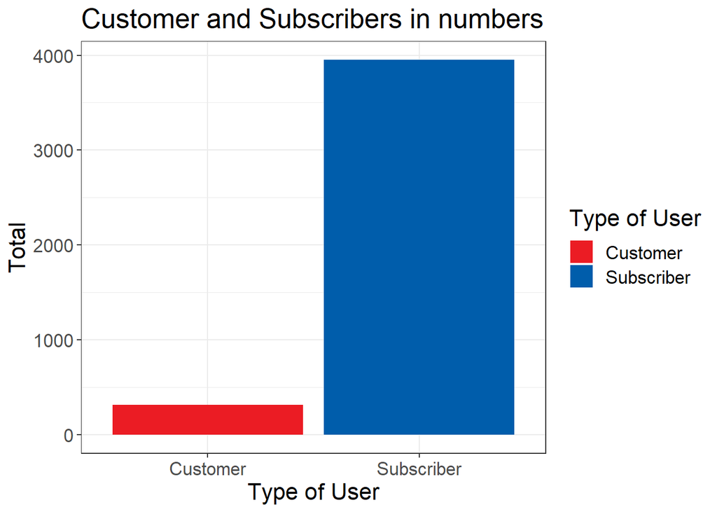

```r
subs_vs_cust <- bikes_data %>%
  ggplot() +
  geom_bar(aes(x = user_type, fill = user_type))+
    scale_fill_manual("Type of User", values = c("Customer" = "#eb1c24",
                                 "Subscriber" = "#005dab")) +
  ggtitle("Customer and Subscribers in numbers") +
  labs(x = "Type of User", y = "Total") +
  theme_bw() +
  theme(text=element_text(size=16,  family = "Mary Ann"))
```

Most of the bikes in this data set are used by Subscribers. Users in the annual plan make almost 4000 thousand bike trips, against short to 300 that Customer make. Now that we have established the numbers, let’s move on analyse the two categories.

**What weekday is the most popular for hiring a bike?**

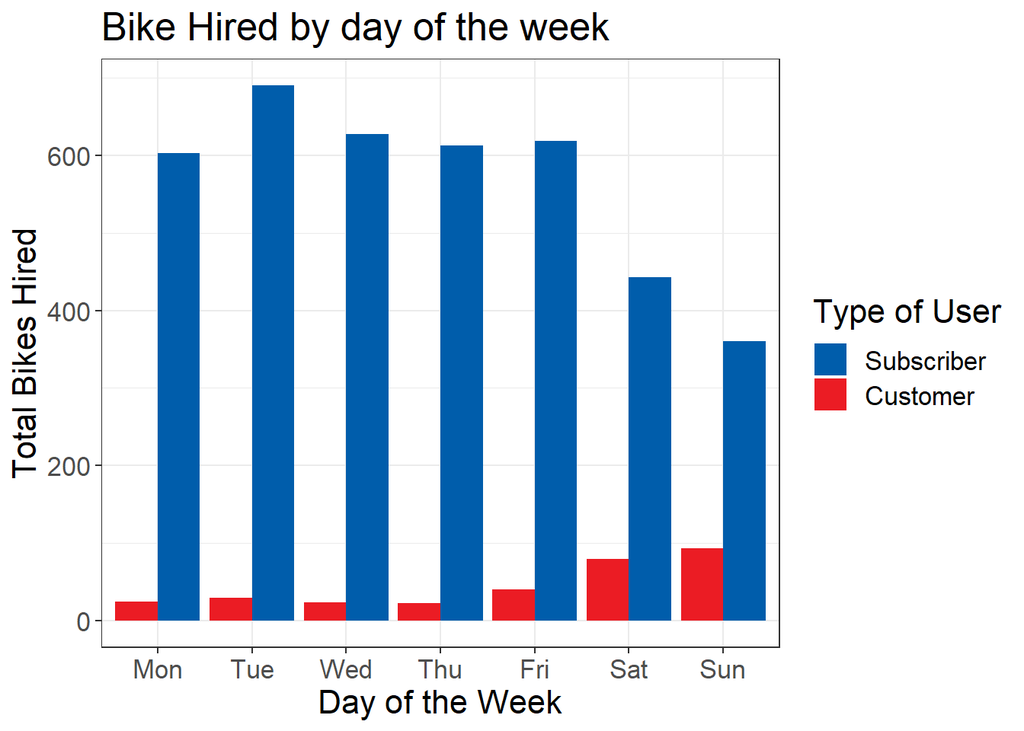

```r
bikes_per_day <- bikes_data %>%
  group_by(hire_day, user_type) %>%
  summarise(total_hire = n())



bikes_per_day$hire_day <- factor(bikes_per_day$hire_day,
                                 levels = c("Mon",
                                            "Tue",
                                            "Wed",
                                            "Thu",
                                            "Fri",
                                            "Sat",
                                            "Sun")
                                 )


bikes_per_day_plot <-  ggplot(bikes_per_day) +
  geom_bar(position = "dodge", stat = "identity", aes(x = hire_day,
                                                     y = total_hire,
                                                     fill = user_type)) +
  labs(x = "Day of the Week", y = "Total Bikes Hired") +
  ggtitle("Bike Hired by day of the week") +
  scale_fill_manual("Type of User", values = c(
                                          "Subscriber" = "#005dab",
                                          "Customer" = "#eb1c24")
                    ) +
  theme_bw() +
  theme(text=element_text(size=16,  family = "Mary Ann"))
```

The numbers are constant during working days, we can see a small pick on Tuesdays. No surprising, most of the users are Subscribers, the Customers numbers are minimal compared to regular users. On the weekend there’s an obvious drop in the numbers but we can see a first interesting difference between the two categories:

Unlike Subscribers, there’s a small peak in Customers numbers. This hints to the main difference between the two categories, people with a Citi Bike subscription are most probably commuter, while Customer users are most probably leisure bikers, looking for a stroll in town during the weekend.

Let’s explore this more in the next visual.

**Average hire length**

```r
hire_lenght <- bikes_data %>%
  arrange(desc(rent_lengt_minutes))

hire_lenght_filtred <- hire_lenght %>%
  filter(rent_lengt_minutes < 700.00000) # In two occasion users have rented bikes for three days. Beside this being against the policy of short lent of Citi Bike I have the feeling this could be a mistake, I don't want the total mean to be pulled by these values so I am going to filter out any bike hire longer than 700 minutes.

avg_run <- hire_lenght_filtred %>%
  group_by(user_type) %>%
  summarise(avg_run = mean(rent_lengt_minutes, na.rm = TRUE))
```

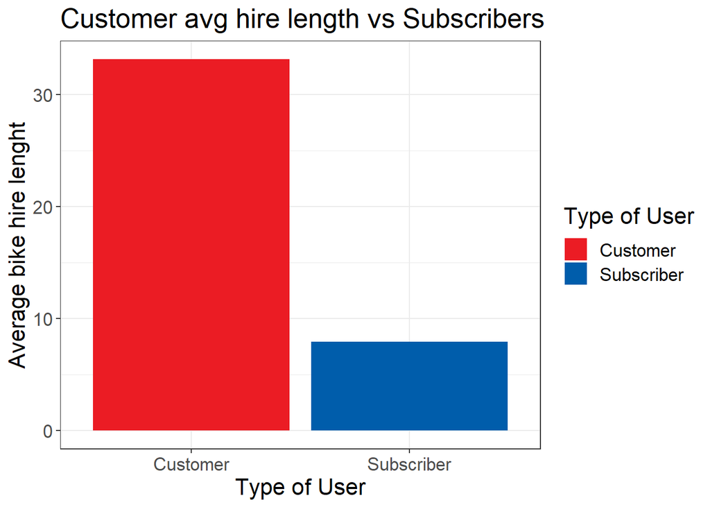

```r
avg_hire_time_users <-  ggplot(avg_run) +
  geom_col(aes(x = user_type, y = avg_run, fill = user_type)) +
  scale_fill_manual("Type of User", values = c("Customer" = "#eb1c24",
                                 "Subscriber" = "#005dab")) +
  ggtitle("Customer avg hire length vs Subscribers") +
  labs(x = "Type of User", y = "Average bike hire lenght") +
  theme_bw() +
  theme(text=element_text(size=16,  family = "Mary Ann"))
```

A clear difference again, Customers ride their bikes in average far more time than Subscribers do. They use in fully the $3.99 worth half an hour on a classic cycle that Citi Bike offers. From this data, is unlike that a Customer will use Citi Bike for a short commute in town rather than jump on Uber for example.

To push more on this point, let’s analyse usage over the year.

**Usage over the year**

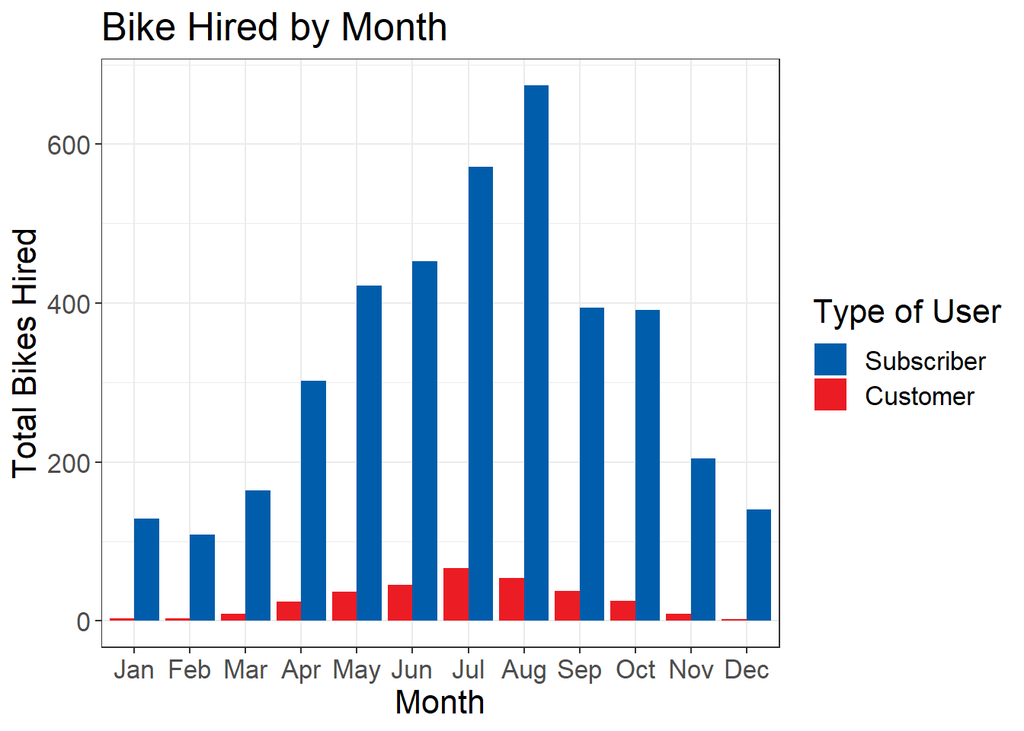

```r
bikes_per_month <- bikes_data %>%
  group_by(hire_month, user_type) %>%
  summarise(total_hire = n())



bikes_per_month$hire_month <- factor(bikes_per_month$hire_month,
                                     levels = c("Jan",
                                                "Feb",
                                                "Mar",
                                                "Apr",
                                                "May",
                                                "Jun",
                                                "Jul",
                                                "Aug",
                                                "Sep",
                                                "Oct",
                                                "Nov",
                                                "Dec")
                                 )

bikes_per_month_plot <-  ggplot(bikes_per_month) +
  geom_bar(position = "dodge", stat = "identity", aes(x = hire_month,
                                                      y = total_hire,
                                                      fill = user_type)) +
  labs(x = "Month", y = "Total Bikes Hired") +
  ggtitle("Bike Hired by Month") +
  scale_fill_manual("Type of User", values = c(
                                          "Subscriber" = "#005dab",
                                          "Customer" = "#eb1c24"
                                          )) +
  theme_bw() +
  theme(text=element_text(size=16,  family = "Mary Ann"))
```

This visual again reiterates the necessity vs leisure of the two categories. Customer forget the existence of Citi Bank until outdoors are liveable again. And just a niche of strong Subscribers uses the service in winter.

Let dig more in these two categories and see if they have any points in common.

**Usage by age**

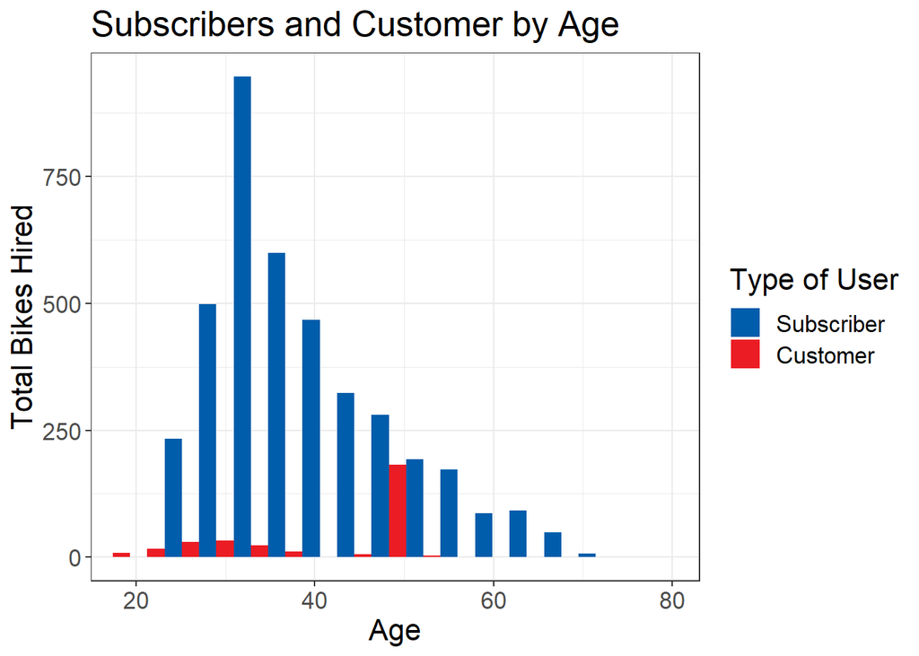

```r
users_age <- bikes_data %>%
  group_by(user_age, user_type) %>%
  summarise(total_hire = n())



user_age_plot <-  ggplot(bikes_data) +
  geom_histogram(position = "dodge", aes(x = user_age, fill = user_type)) +
  coord_cartesian(xlim = c(18, 80)) +  # keeping the age in the plot between 18-80 years old. There a couple of user aged 133 years in the data set, a clear mistake.
  ggtitle("Subscribers and Customer by Age") +
  labs(x = "Age", y = "Total Bikes Hired") +
  scale_fill_manual("Type of User", values = c(
                                          "Subscriber" = "#005dab",
                                          "Customer" = "#eb1c24"
                                          )) +
  theme_bw() +
  theme(text=element_text(size=16,  family = "Mary Ann"))
```

In this plot we can see the age of Citi Bank users’ part of this dataset. The majority of the Subscribers are in their late 20s early 30s. The Customer age is mostly flat, we can see a small rise within the same 25 to 35 years old range, although not has dramatic like in the Subscribers.

The anomaly in this data set are 49 years old. 180 Customer bike hiring were made by 49 years old users. This spark could be from a single user (or more than one user coincidentally of the same age) or an error during data collection. I cannot be sure is the latter so I have decided to leave it in the visual.

**Customer and Subscribers by area**

```r
customer_map <- bikes_data %>%
  filter(user_type == "Customer")

ny_map_cust <- leaflet(customer_map) %>%
  addTiles() %>%
  addCircleMarkers(lng = ~start_long,
                   lat = ~end_lat, radius = ~bike_id/3000, weight = 1)

ny_map_cust
```

[interactive chart not shown]

On the map above we can see bike stations used by Customer, specifically starting station and ending station of different trips. We notice they stay for the most central with very few users adventuring away towards the suburbs. This visual it’s not suggesting a commuting pattern

Let’s compare it this with Subscribers.

```r
sub_map <- bikes_data %>%
  filter(user_type == "Subscriber")


ny_map_sub_cluster <-leaflet(sub_map) %>%
  addTiles() %>%
  addCircleMarkers(lng = ~start_long,
                   lat = ~end_lat,
                   clusterOptions = markerClusterOptions())

ny_map_sub_cluster_marker <- leaflet(sub_map) %>%
  addTiles() %>%
  addCircleMarkers(lng = ~start_long,
                   lat = ~end_lat, radius = ~bike_id/3000, weight = 1)

ny_map_sub_cluster
```

[interactive chart not shown]

```r
ny_map_sub_cluster_marker
```

[interactive chart not shown]

On the two maps above we can see bike stations used by Subscribes. Again, specifically starting station and ending station of different trips.

Select the Cluster Map for a cleaner visual.

The difference is clear, Subscribers are not relegated just in the city centre, but have a larger range than Customer, covering more ground.

Again, a strong hint of a commuting pattern.

## Conclusions

To answer the questions at the beginning of the analysis:

- Do Subscribers and Customer use the service for different purpose?

**Yes, the data suggest that a user with a subscription is more likely to use Citi Bike for short commuting on a daily base during working days. On the other hand a Customer would use Citi Bike mostly for leisure, on a weekend on a summer month riding longer in average than a Subscriber.**

- Do they have any characteristic in common?

**Not really, Subscribers show an age pattern while Customer don’t, they have a small increase to the same age range (25 to 35) where Subscribers peak but this is barely noticeable. Their average hire length is totally different.**

- Is there a way to attract Customers to a subscription plan?

**Before starting this analysis I would have believed that many Customers were drove away by the one year subscription plan, not wanting to commit this long especially having in mind winter months. Now after looking at the two categories I can’t say this to be true. They are two different categories with two different needs**

- Does Citi Bike need a new membership option, like a trimester subscription plan?

**Not necessarily. I’d suggest a trail on a trimester subscription plan for summer month or a weekend plan, in particular aimed to the 25-35 age group. Anyhow there’s no suggestion in the data that this will translate in an increase in subscriptions.**